# 2547138_lab4

Breast Cancer Wisconsin Diagnostic Dataset - Lab 4

```python
import numpy as np
import pandas as pd
import matplotlib.pyplot as plt
import seaborn as sns

from IPython.display import display
from matplotlib.colors import ListedColormap
from matplotlib.patches import Patch
from sklearn.decomposition import PCA
from sklearn.metrics import accuracy_score, confusion_matrix, f1_score, precision_score, recall_score, roc_auc_score, roc_curve
from sklearn.model_selection import StratifiedKFold, cross_val_score, train_test_split
from sklearn.neighbors import KNeighborsClassifier
from sklearn.preprocessing import LabelEncoder, StandardScaler

sns.set_theme(style='whitegrid')
pd.set_option('display.max_columns', None)
```

Task 1 - Data Preparation

```python
df_raw = pd.read_csv('brca.csv')

display(df_raw.head())
display(df_raw.tail())
print('Dataset shape:', df_raw.shape)
print('Column names:', list(df_raw.columns))
print('Data types:')
display(df_raw.dtypes.to_frame(name='dtype'))
print('Dataset information:')
df_raw.info()
print('Descriptive statistics:')
display(df_raw.describe())
print('Missing values:')
display(df_raw.isna().sum().to_frame(name='missing_values'))
print('Duplicate records:', df_raw.duplicated().sum())

df_clean = df_raw.rename(columns={df_raw.columns[0]: 'id', 'y': 'diagnosis'}).copy()

if df_clean.isna().sum().sum() > 0:
    numeric_columns = df_clean.select_dtypes(include=[np.number]).columns
    df_clean[numeric_columns] = df_clean[numeric_columns].fillna(df_clean[numeric_columns].median())
    categorical_columns = df_clean.select_dtypes(exclude=[np.number]).columns
    for column in categorical_columns:
        df_clean[column] = df_clean[column].fillna(df_clean[column].mode().iloc[0])

duplicate_count = df_clean.duplicated().sum()
df_clean = df_clean.drop_duplicates().reset_index(drop=True)
print('Duplicate records removed:', duplicate_count)

label_encoder = LabelEncoder()
df_clean['diagnosis_encoded'] = label_encoder.fit_transform(df_clean['diagnosis'])
print('Diagnosis encoding:', dict(zip(label_encoder.classes_, label_encoder.transform(label_encoder.classes_))))

feature_columns = [column for column in df_clean.columns if column not in ['id', 'diagnosis', 'diagnosis_encoded']]
X = df_clean[feature_columns]
y = df_clean['diagnosis_encoded']

scaler = StandardScaler()
X_scaled = scaler.fit_transform(X)
X_scaled_df = pd.DataFrame(X_scaled, columns=feature_columns)

print('Scaled feature matrix shape:', X_scaled_df.shape)
print('Feature columns used for KNN:')
print(feature_columns)
```

|  | Unnamed: 0 | x.radius_mean | x.texture_mean | x.perimeter_mean | x.area_mean | x.smoothness_mean | x.compactness_mean | x.concavity_mean | x.concave_pts_mean | x.symmetry_mean | x.fractal_dim_mean | x.radius_se | x.texture_se | x.perimeter_se | x.area_se | x.smoothness_se | x.compactness_se | x.concavity_se | x.concave_pts_se | x.symmetry_se | x.fractal_dim_se | x.radius_worst | x.texture_worst | x.perimeter_worst | x.area_worst | x.smoothness_worst | x.compactness_worst | x.concavity_worst | x.concave_pts_worst | … |
| --- | --- | --- | --- | --- | --- | --- | --- | --- | --- | --- | --- | --- | --- | --- | --- | --- | --- | --- | --- | --- | --- | --- | --- | --- | --- | --- | --- | --- | --- | --- |
| 0 | 1 | 13.540 | 14.36 | 87.46 | 566.3 | 0.09779 | 0.08129 | 0.06664 | 0.047810 | 0.1885 | 0.05766 | 0.2699 | 0.7886 | 2.058 | 23.560 | 0.008462 | 0.014600 | 0.02387 | 0.013150 | 0.01980 | 0.002300 | 15.110 | 19.26 | 99.70 | 711.2 | 0.14400 | 0.17730 | 0.23900 | 0.12880 | … |
| 1 | 2 | 13.080 | 15.71 | 85.63 | 520.0 | 0.10750 | 0.12700 | 0.04568 | 0.031100 | 0.1967 | 0.06811 | 0.1852 | 0.7477 | 1.383 | 14.670 | 0.004097 | 0.018980 | 0.01698 | 0.006490 | 0.01678 | 0.002425 | 14.500 | 20.49 | 96.09 | 630.5 | 0.13120 | 0.27760 | 0.18900 | 0.07283 | … |
| 2 | 3 | 9.504 | 12.44 | 60.34 | 273.9 | 0.10240 | 0.06492 | 0.02956 | 0.020760 | 0.1815 | 0.06905 | 0.2773 | 0.9768 | 1.909 | 15.700 | 0.009606 | 0.014320 | 0.01985 | 0.014210 | 0.02027 | 0.002968 | 10.230 | 15.66 | 65.13 | 314.9 | 0.13240 | 0.11480 | 0.08867 | 0.06227 | … |
| 3 | 4 | 13.030 | 18.42 | 82.61 | 523.8 | 0.08983 | 0.03766 | 0.02562 | 0.029230 | 0.1467 | 0.05863 | 0.1839 | 2.3420 | 1.170 | 14.160 | 0.004352 | 0.004899 | 0.01343 | 0.011640 | 0.02671 | 0.001777 | 13.300 | 22.81 | 84.46 | 545.9 | 0.09701 | 0.04619 | 0.04833 | 0.05013 | … |
| 4 | 5 | 8.196 | 16.84 | 51.71 | 201.9 | 0.08600 | 0.05943 | 0.01588 | 0.005917 | 0.1769 | 0.06503 | 0.1563 | 0.9567 | 1.094 | 8.205 | 0.008968 | 0.016460 | 0.01588 | 0.005917 | 0.02574 | 0.002582 | 8.964 | 21.96 | 57.26 | 242.2 | 0.12970 | 0.13570 | 0.06880 | 0.02564 | … |

|  | Unnamed: 0 | x.radius_mean | x.texture_mean | x.perimeter_mean | x.area_mean | x.smoothness_mean | x.compactness_mean | x.concavity_mean | x.concave_pts_mean | x.symmetry_mean | x.fractal_dim_mean | x.radius_se | x.texture_se | x.perimeter_se | x.area_se | x.smoothness_se | x.compactness_se | x.concavity_se | x.concave_pts_se | x.symmetry_se | x.fractal_dim_se | x.radius_worst | x.texture_worst | x.perimeter_worst | x.area_worst | x.smoothness_worst | x.compactness_worst | x.concavity_worst | x.concave_pts_worst | … |
| --- | --- | --- | --- | --- | --- | --- | --- | --- | --- | --- | --- | --- | --- | --- | --- | --- | --- | --- | --- | --- | --- | --- | --- | --- | --- | --- | --- | --- | --- | --- |
| 564 | 565 | 20.92 | 25.09 | 143.0 | 1347.0 | 0.10990 | 0.2236 | 0.31740 | 0.14740 | 0.2149 | 0.06879 | 0.9622 | 1.026 | 8.758 | 118.80 | 0.006399 | 0.04310 | 0.07845 | 0.02624 | 0.02057 | 0.006213 | 24.29 | 29.41 | 179.1 | 1819.0 | 0.1407 | 0.4186 | 0.6599 | 0.2542 | … |
| 565 | 566 | 21.56 | 22.39 | 142.0 | 1479.0 | 0.11100 | 0.1159 | 0.24390 | 0.13890 | 0.1726 | 0.05623 | 1.1760 | 1.256 | 7.673 | 158.70 | 0.010300 | 0.02891 | 0.05198 | 0.02454 | 0.01114 | 0.004239 | 25.45 | 26.40 | 166.1 | 2027.0 | 0.1410 | 0.2113 | 0.4107 | 0.2216 | … |
| 566 | 567 | 20.13 | 28.25 | 131.2 | 1261.0 | 0.09780 | 0.1034 | 0.14400 | 0.09791 | 0.1752 | 0.05533 | 0.7655 | 2.463 | 5.203 | 99.04 | 0.005769 | 0.02423 | 0.03950 | 0.01678 | 0.01898 | 0.002498 | 23.69 | 38.25 | 155.0 | 1731.0 | 0.1166 | 0.1922 | 0.3215 | 0.1628 | … |
| 567 | 568 | 16.60 | 28.08 | 108.3 | 858.1 | 0.08455 | 0.1023 | 0.09251 | 0.05302 | 0.1590 | 0.05648 | 0.4564 | 1.075 | 3.425 | 48.55 | 0.005903 | 0.03731 | 0.04730 | 0.01557 | 0.01318 | 0.003892 | 18.98 | 34.12 | 126.7 | 1124.0 | 0.1139 | 0.3094 | 0.3403 | 0.1418 | … |
| 568 | 569 | 20.60 | 29.33 | 140.1 | 1265.0 | 0.11780 | 0.2770 | 0.35140 | 0.15200 | 0.2397 | 0.07016 | 0.7260 | 1.595 | 5.772 | 86.22 | 0.006522 | 0.06158 | 0.07117 | 0.01664 | 0.02324 | 0.006185 | 25.74 | 39.42 | 184.6 | 1821.0 | 0.1650 | 0.8681 | 0.9387 | 0.2650 | … |

```
Dataset shape: (569, 32)
Column names: ['Unnamed: 0', 'x.radius_mean', 'x.texture_mean', 'x.perimeter_mean', 'x.area_mean', 'x.smoothness_mean', 'x.compactness_mean', 'x.concavity_mean', 'x.concave_pts_mean', 'x.symmetry_mean', 'x.fractal_dim_mean', 'x.radius_se', 'x.texture_se', 'x.perimeter_se', 'x.area_se', 'x.smoothness…
Data types:
```

|  | dtype |
| --- | --- |
| Unnamed: 0 | int64 |
| x.radius_mean | float64 |
| x.texture_mean | float64 |
| x.perimeter_mean | float64 |
| x.area_mean | float64 |
| x.smoothness_mean | float64 |
| x.compactness_mean | float64 |
| x.concavity_mean | float64 |
| x.concave_pts_mean | float64 |
| x.symmetry_mean | float64 |
| x.fractal_dim_mean | float64 |
| x.radius_se | float64 |
| x.texture_se | float64 |
| x.perimeter_se | float64 |
| x.area_se | float64 |
| x.smoothness_se | float64 |
| x.compactness_se | float64 |
| x.concavity_se | float64 |
| x.concave_pts_se | float64 |
| x.symmetry_se | float64 |
| x.fractal_dim_se | float64 |
| x.radius_worst | float64 |
| x.texture_worst | float64 |
| x.perimeter_worst | float64 |
| x.area_worst | float64 |
| x.smoothness_worst | float64 |
| x.compactness_worst | float64 |
| x.concavity_worst | float64 |
| x.concave_pts_worst | float64 |
| x.symmetry_worst | float64 |
| x.fractal_dim_worst | float64 |
| y | str |

```
Dataset information:
<class 'pandas.DataFrame'>
RangeIndex: 569 entries, 0 to 568
Data columns (total 32 columns):
 #   Column               Non-Null Count  Dtype
---  ------               --------------  -----
 0   Unnamed: 0           569 non-null    int64
 1   x.radius_mean        569 non-null    float64
 2   x.texture_mean       569 non-null    float64
 3   x.perimeter_mean     569 non-null    float64
 4   x.area_mean          569 non-null    float64
 5   x.smoothness_mean    569 non-null    float64
 6   x.compactness_mean   569 non-null    float64
 7   x.concavity_mean     569 non-null    float64
 8   x.concave_pts_mean   569 non-null    float64
```

[output cut: 26 more lines]

|  | Unnamed: 0 | x.radius_mean | x.texture_mean | x.perimeter_mean | x.area_mean | x.smoothness_mean | x.compactness_mean | x.concavity_mean | x.concave_pts_mean | x.symmetry_mean | x.fractal_dim_mean | x.radius_se | x.texture_se | x.perimeter_se | x.area_se | x.smoothness_se | x.compactness_se | x.concavity_se | x.concave_pts_se | x.symmetry_se | x.fractal_dim_se | x.radius_worst | x.texture_worst | x.perimeter_worst | x.area_worst | x.smoothness_worst | x.compactness_worst | x.concavity_worst | x.concave_pts_worst | … |
| --- | --- | --- | --- | --- | --- | --- | --- | --- | --- | --- | --- | --- | --- | --- | --- | --- | --- | --- | --- | --- | --- | --- | --- | --- | --- | --- | --- | --- | --- | --- |
| count | 569.000000 | 569.000000 | 569.000000 | 569.000000 | 569.000000 | 569.000000 | 569.000000 | 569.000000 | 569.000000 | 569.000000 | 569.000000 | 569.000000 | 569.000000 | 569.000000 | 569.000000 | 569.000000 | 569.000000 | 569.000000 | 569.000000 | 569.000000 | 569.000000 | 569.000000 | 569.000000 | 569.000000 | 569.000000 | 569.000000 | 569.000000 | 569.000000 | 569.000000 | … |
| mean | 285.000000 | 14.127292 | 19.289649 | 91.969033 | 654.889104 | 0.096360 | 0.104341 | 0.088799 | 0.048919 | 0.181162 | 0.062798 | 0.405172 | 1.216853 | 2.866059 | 40.337079 | 0.007041 | 0.025478 | 0.031894 | 0.011796 | 0.020542 | 0.003795 | 16.269190 | 25.677223 | 107.261213 | 880.583128 | 0.132369 | 0.254265 | 0.272188 | 0.114606 | … |
| std | 164.400426 | 3.524049 | 4.301036 | 24.298981 | 351.914129 | 0.014064 | 0.052813 | 0.079720 | 0.038803 | 0.027414 | 0.007060 | 0.277313 | 0.551648 | 2.021855 | 45.491006 | 0.003003 | 0.017908 | 0.030186 | 0.006170 | 0.008266 | 0.002646 | 4.833242 | 6.146258 | 33.602542 | 569.356993 | 0.022832 | 0.157336 | 0.208624 | 0.065732 | … |
| min | 1.000000 | 6.981000 | 9.710000 | 43.790000 | 143.500000 | 0.052630 | 0.019380 | 0.000000 | 0.000000 | 0.106000 | 0.049960 | 0.111500 | 0.360200 | 0.757000 | 6.802000 | 0.001713 | 0.002252 | 0.000000 | 0.000000 | 0.007882 | 0.000895 | 7.930000 | 12.020000 | 50.410000 | 185.200000 | 0.071170 | 0.027290 | 0.000000 | 0.000000 | … |
| 25% | 143.000000 | 11.700000 | 16.170000 | 75.170000 | 420.300000 | 0.086370 | 0.064920 | 0.029560 | 0.020310 | 0.161900 | 0.057700 | 0.232400 | 0.833900 | 1.606000 | 17.850000 | 0.005169 | 0.013080 | 0.015090 | 0.007638 | 0.015160 | 0.002248 | 13.010000 | 21.080000 | 84.110000 | 515.300000 | 0.116600 | 0.147200 | 0.114500 | 0.064930 | … |
| 50% | 285.000000 | 13.370000 | 18.840000 | 86.240000 | 551.100000 | 0.095870 | 0.092630 | 0.061540 | 0.033500 | 0.179200 | 0.061540 | 0.324200 | 1.108000 | 2.287000 | 24.530000 | 0.006380 | 0.020450 | 0.025890 | 0.010930 | 0.018730 | 0.003187 | 14.970000 | 25.410000 | 97.660000 | 686.500000 | 0.131300 | 0.211900 | 0.226700 | 0.099930 | … |
| 75% | 427.000000 | 15.780000 | 21.800000 | 104.100000 | 782.700000 | 0.105300 | 0.130400 | 0.130700 | 0.074000 | 0.195700 | 0.066120 | 0.478900 | 1.474000 | 3.357000 | 45.190000 | 0.008146 | 0.032450 | 0.042050 | 0.014710 | 0.023480 | 0.004558 | 18.790000 | 29.720000 | 125.400000 | 1084.000000 | 0.146000 | 0.339100 | 0.382900 | 0.161400 | … |
| max | 569.000000 | 28.110000 | 39.280000 | 188.500000 | 2501.000000 | 0.163400 | 0.345400 | 0.426800 | 0.201200 | 0.304000 | 0.097440 | 2.873000 | 4.885000 | 21.980000 | 542.200000 | 0.031130 | 0.135400 | 0.396000 | 0.052790 | 0.078950 | 0.029840 | 36.040000 | 49.540000 | 251.200000 | 4254.000000 | 0.222600 | 1.058000 | 1.252000 | 0.291000 | … |

```
Missing values:
```

|  | missing_values |
| --- | --- |
| Unnamed: 0 | 0 |
| x.radius_mean | 0 |
| x.texture_mean | 0 |
| x.perimeter_mean | 0 |
| x.area_mean | 0 |
| x.smoothness_mean | 0 |
| x.compactness_mean | 0 |
| x.concavity_mean | 0 |
| x.concave_pts_mean | 0 |
| x.symmetry_mean | 0 |
| x.fractal_dim_mean | 0 |
| x.radius_se | 0 |
| x.texture_se | 0 |
| x.perimeter_se | 0 |
| x.area_se | 0 |
| x.smoothness_se | 0 |
| x.compactness_se | 0 |
| x.concavity_se | 0 |
| x.concave_pts_se | 0 |
| x.symmetry_se | 0 |
| x.fractal_dim_se | 0 |
| x.radius_worst | 0 |
| x.texture_worst | 0 |
| x.perimeter_worst | 0 |
| x.area_worst | 0 |
| x.smoothness_worst | 0 |
| x.compactness_worst | 0 |
| x.concavity_worst | 0 |
| x.concave_pts_worst | 0 |
| x.symmetry_worst | 0 |
| x.fractal_dim_worst | 0 |
| y | 0 |

[output not shown]

Feature scaling is important for KNN because the algorithm uses distance between points. StandardScaler makes sure no single feature dominates just because it has larger numeric values.

Inference: The dataset was loaded, checked, and prepared for KNN. The target was encoded and the features were scaled so distance-based comparison is fair.

Task 2 - Train-Test Split Analysis

|  | split | train_size | test_size | accuracy |
| --- | --- | --- | --- | --- |
| 0 | 80:20 | 455 | 114 | 0.956140 |
| 1 | 70:30 | 398 | 171 | 0.964912 |
| 2 | 90:10 | 512 | 57 | 0.964912 |

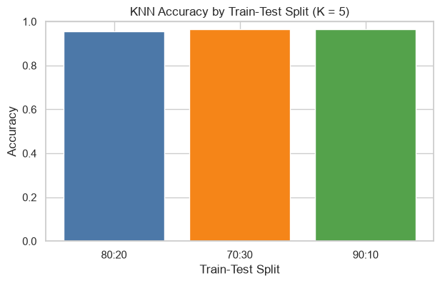

```python
def evaluate_split(test_size, k_value, random_state=42):
    X_train, X_test, y_train, y_test = train_test_split(
        X_scaled, y, test_size=test_size, random_state=random_state, stratify=y
    )
    model = KNeighborsClassifier(n_neighbors=k_value)
    model.fit(X_train, y_train)
    predictions = model.predict(X_test)
    return {
        'split': f'{int((1 - test_size) * 100)}:{int(test_size * 100)}',
        'train_size': len(X_train),
        'test_size': len(X_test),
        'accuracy': accuracy_score(y_test, predictions)
    }

initial_k = 5
split_results = pd.DataFrame([
    evaluate_split(0.2, initial_k),
    evaluate_split(0.3, initial_k),
    evaluate_split(0.1, initial_k),
])
split_results = split_results[['split', 'train_size', 'test_size', 'accuracy']]
display(split_results)

plt.figure(figsize=(7, 4))
plt.bar(split_results['split'], split_results['accuracy'], color=['#4C78A8', '#F58518', '#54A24B'])
plt.title('KNN Accuracy by Train-Test Split (K = 5)')
plt.xlabel('Train-Test Split')
plt.ylabel('Accuracy')
plt.ylim(0, 1)
plt.show()
```

Inference: The table and bar chart show how the same K value behaves under different split ratios. The best split is the one with the highest accuracy in the output table.

Task 3 - Heuristic K Selection

```python
X_train_80, X_test_80, y_train_80, y_test_80 = train_test_split(
    X_scaled, y, test_size=0.2, random_state=42, stratify=y
)

n_train = len(X_train_80)
raw_k = np.sqrt(n_train)
rounded_k = int(round(raw_k))
if rounded_k % 2 == 1:
    heuristic_k = rounded_k
else:
    lower_k = max(1, rounded_k - 1)
    upper_k = rounded_k + 1
    heuristic_k = lower_k if abs(raw_k - lower_k) <= abs(upper_k - raw_k) else upper_k

print('Training samples:', n_train)
print('Raw sqrt(n):', raw_k)
print('Heuristic K (odd):', heuristic_k)

heuristic_model = KNeighborsClassifier(n_neighbors=heuristic_k)
heuristic_model.fit(X_train_80, y_train_80)
heuristic_predictions = heuristic_model.predict(X_test_80)
heuristic_accuracy = accuracy_score(y_test_80, heuristic_predictions)
print('Heuristic K test accuracy:', heuristic_accuracy)
```

```
Training samples: 455
Raw sqrt(n): 21.330729007701542
Heuristic K (odd): 21
Heuristic K test accuracy: 0.9385964912280702
```

Odd K is usually preferred because it reduces the chance of a tie when the neighbors vote. That makes the prediction decision simpler and more stable.

Inference: The heuristic K was computed from the training size and then adjusted to an odd number. The model was trained with that K and its holdout accuracy was measured.

K Optimization

|  | k | test_accuracy |
| --- | --- | --- |
| 0 | 16 | 0.938596 |
| 1 | 17 | 0.938596 |
| 2 | 18 | 0.938596 |
| 3 | 19 | 0.938596 |
| 4 | 20 | 0.938596 |
| 5 | 21 | 0.938596 |
| 6 | 22 | 0.938596 |
| 7 | 23 | 0.938596 |
| 8 | 24 | 0.947368 |
| 9 | 25 | 0.947368 |
| 10 | 26 | 0.947368 |

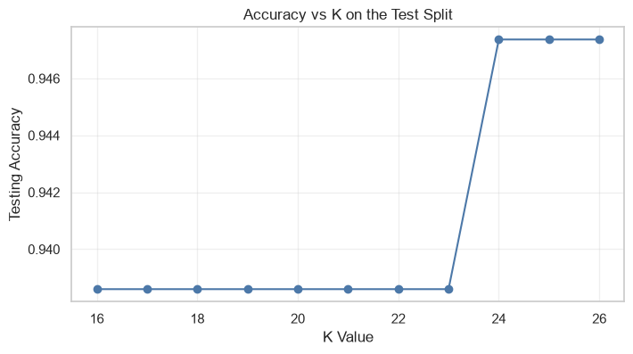

```
Best K from testing accuracy: 24
Best testing accuracy: 0.9473684210526315
```

```python
k_start = max(1, heuristic_k - 5)
k_end = heuristic_k + 5
k_values = list(range(k_start, k_end + 1))

optimization_rows = []
for k in k_values:
    model = KNeighborsClassifier(n_neighbors=k)
    model.fit(X_train_80, y_train_80)
    predictions = model.predict(X_test_80)
    optimization_rows.append({
        'k': k,
        'test_accuracy': accuracy_score(y_test_80, predictions)
    })

optimization_results = pd.DataFrame(optimization_rows)
display(optimization_results)

plt.figure(figsize=(8, 4))
plt.plot(optimization_results['k'], optimization_results['test_accuracy'], marker='o', color='#4C78A8')
plt.title('Accuracy vs K on the Test Split')
plt.xlabel('K Value')
plt.ylabel('Testing Accuracy')
plt.grid(True, alpha=0.3)
plt.show()

best_test_row = optimization_results.loc[optimization_results['test_accuracy'].idxmax()]
best_k_test = int(best_test_row['k'])
best_test_accuracy = float(best_test_row['test_accuracy'])
print('Best K from testing accuracy:', best_k_test)
print('Best testing accuracy:', best_test_accuracy)
```

Inference: The accuracy curve shows how performance changes as K grows. The selected K is the one with the highest testing accuracy in the table.

Distance Metrics

**Euclidean Distance** measures the straight-line distance between two points. It is the most common distance metric for KNN when features are scaled properly. It works well when nearby points in all directions should be treated similarly.

**Manhattan Distance** measures distance by adding the absolute differences across features. It can be useful when the data has many dimensions or when outliers affect straight-line distance too much. It is often preferred when movement is more grid-like than diagonal.

Euclidean distance is often preferred for smooth numeric data. Manhattan distance is often preferred when the feature space is sparse or noisy.

Decision Boundary

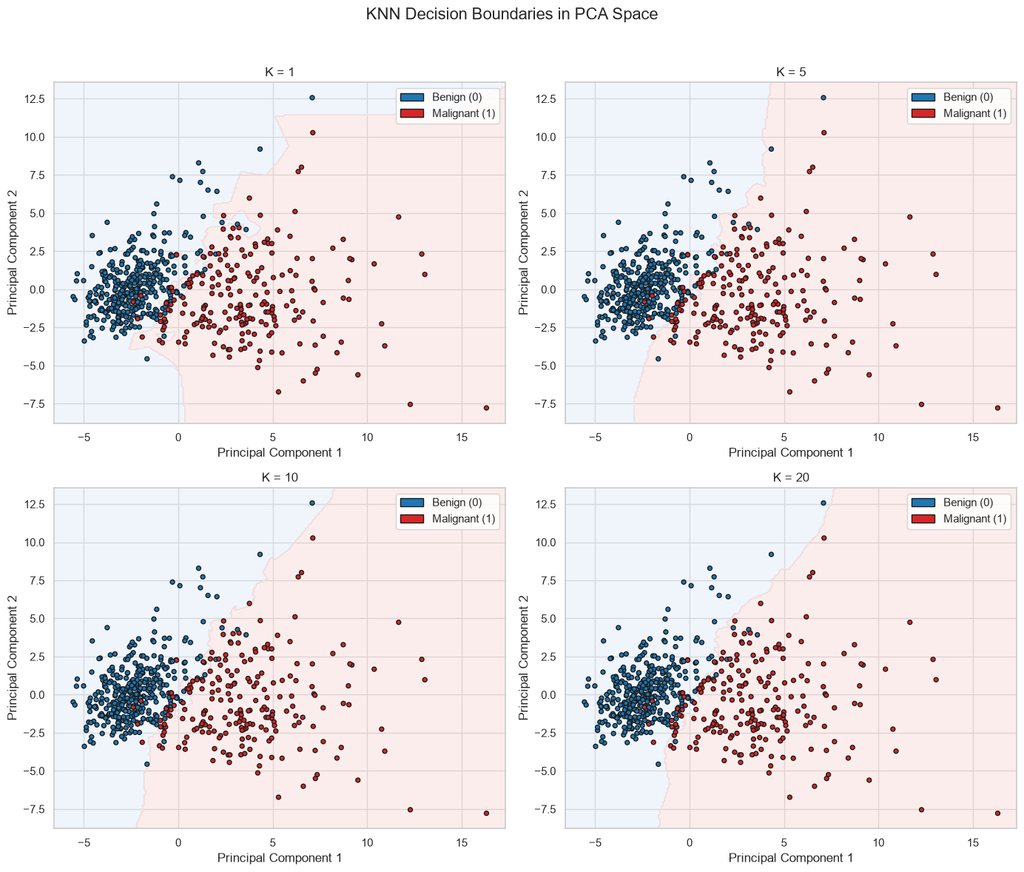

```python
pca = PCA(n_components=2, random_state=42)
X_pca = pca.fit_transform(X_scaled)

def plot_boundary(ax, X_data, y_data, k_value):
    model = KNeighborsClassifier(n_neighbors=k_value)
    model.fit(X_data, y_data)
    x_min, x_max = X_data[:, 0].min() - 1, X_data[:, 0].max() + 1
    y_min, y_max = X_data[:, 1].min() - 1, X_data[:, 1].max() + 1
    xx, yy = np.meshgrid(np.linspace(x_min, x_max, 300), np.linspace(y_min, y_max, 300))
    grid_predictions = model.predict(np.c_[xx.ravel(), yy.ravel()]).reshape(xx.shape)
    boundary_cmap = ListedColormap(['#dce9f7', '#f8d9d7'])
    point_cmap = ListedColormap(['#1f77b4', '#d62728'])
    ax.contourf(xx, yy, grid_predictions, alpha=0.45, cmap=boundary_cmap)
    ax.scatter(X_data[:, 0], X_data[:, 1], c=y_data, cmap=point_cmap, edgecolor='k', s=18)
    ax.set_title(f'K = {k_value}')
    ax.set_xlabel('Principal Component 1')
    ax.set_ylabel('Principal Component 2')
    legend_handles = [
        Patch(facecolor='#1f77b4', edgecolor='k', label='Benign (0)'),
        Patch(facecolor='#d62728', edgecolor='k', label='Malignant (1)')
    ]
    ax.legend(handles=legend_handles, loc='best')

fig, axes = plt.subplots(2, 2, figsize=(14, 12))
for ax, k_value in zip(axes.ravel(), [1, 5, 10, 20]):
    plot_boundary(ax, X_pca, y.values, k_value)

fig.suptitle('KNN Decision Boundaries in PCA Space', fontsize=16)
plt.tight_layout(rect=[0, 0, 1, 0.96])
plt.show()
```

For K = 1, the boundary is usually the most jagged because each point can strongly influence its neighborhood.

For K = 5, the boundary should look smoother and less sensitive to isolated points.

For K = 10, the model usually becomes more generalized and the boundary grows more stable.

For K = 20, the boundary is typically the smoothest and can start to ignore smaller local patterns.

Task 4 - Cross Validation

|  | k | train_test_accuracy | cv_mean_accuracy | cv_std | combined_score |
| --- | --- | --- | --- | --- | --- |
| 0 | 16 | 0.938596 | 0.957848 | 0.012835 | 0.948222 |
| 1 | 17 | 0.938596 | 0.961357 | 0.011851 | 0.949977 |
| 2 | 18 | 0.938596 | 0.954339 | 0.017841 | 0.946468 |
| 3 | 19 | 0.938596 | 0.952585 | 0.020412 | 0.945591 |
| 4 | 20 | 0.938596 | 0.950831 | 0.018004 | 0.944714 |
| 5 | 21 | 0.938596 | 0.947322 | 0.022821 | 0.942959 |
| 6 | 22 | 0.938596 | 0.949076 | 0.020252 | 0.943836 |
| 7 | 23 | 0.938596 | 0.947322 | 0.022821 | 0.942959 |
| 8 | 24 | 0.947368 | 0.949076 | 0.020252 | 0.948222 |
| 9 | 25 | 0.947368 | 0.952585 | 0.019643 | 0.949977 |
| 10 | 26 | 0.947368 | 0.950831 | 0.018839 | 0.949100 |

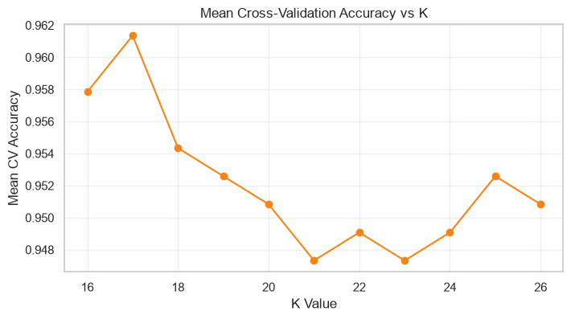

```
Final best K: 17
Combined score: 0.9499767116907313
```

```python
cv = StratifiedKFold(n_splits=5, shuffle=True, random_state=42)
cross_validation_rows = []

for k in k_values:
    model = KNeighborsClassifier(n_neighbors=k)
    cv_scores = cross_val_score(model, X_scaled, y, cv=cv, scoring='accuracy')
    holdout_accuracy = optimization_results.loc[optimization_results['k'] == k, 'test_accuracy'].iloc[0]
    cross_validation_rows.append({
        'k': k,
        'train_test_accuracy': holdout_accuracy,
        'cv_mean_accuracy': cv_scores.mean(),
        'cv_std': cv_scores.std()
    })

cv_results = pd.DataFrame(cross_validation_rows)
cv_results['combined_score'] = cv_results[['train_test_accuracy', 'cv_mean_accuracy']].mean(axis=1)
display(cv_results)

plt.figure(figsize=(8, 4))
plt.plot(cv_results['k'], cv_results['cv_mean_accuracy'], marker='o', color='#F58518')
plt.title('Mean Cross-Validation Accuracy vs K')
plt.xlabel('K Value')
plt.ylabel('Mean CV Accuracy')
plt.grid(True, alpha=0.3)
plt.show()

final_best_row = cv_results.sort_values(['combined_score', 'cv_mean_accuracy', 'train_test_accuracy'], ascending=False).iloc[0]
final_best_k = int(final_best_row['k'])
print('Final best K:', final_best_k)
print('Combined score:', float(final_best_row['combined_score']))
```

Inference: The comparison table shows both holdout accuracy and 5-fold cross-validation accuracy for each K. The final K is chosen using the strongest overall balance between the two scores.

Task 5 - Final Model Evaluation

```python
final_model = KNeighborsClassifier(n_neighbors=final_best_k)
final_model.fit(X_train_80, y_train_80)
final_predictions = final_model.predict(X_test_80)
final_probabilities = final_model.predict_proba(X_test_80)[:, 1]

final_metrics = pd.DataFrame([
    {'Metric': 'Accuracy', 'Value': accuracy_score(y_test_80, final_predictions)},
    {'Metric': 'Precision', 'Value': precision_score(y_test_80, final_predictions)},
    {'Metric': 'Recall', 'Value': recall_score(y_test_80, final_predictions)},
    {'Metric': 'F1 Score', 'Value': f1_score(y_test_80, final_predictions)},
    {'Metric': 'ROC-AUC Score', 'Value': roc_auc_score(y_test_80, final_probabilities)}
])
display(final_metrics)
```

|  | Metric | Value |
| --- | --- | --- |
| 0 | Accuracy | 0.938596 |
| 1 | Precision | 0.972973 |
| 2 | Recall | 0.857143 |
| 3 | F1 Score | 0.911392 |
| 4 | ROC-AUC Score | 0.995040 |

Inference: The metrics table shows how the final KNN model performs on the holdout test set. Recall and ROC-AUC are especially important to check for cancer detection.

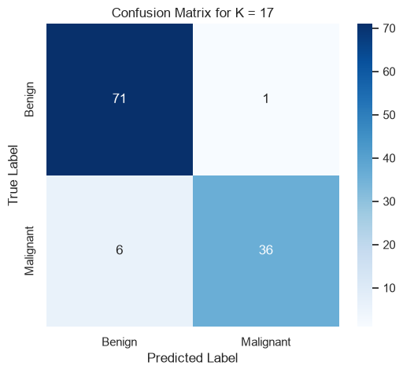

```python
cm = confusion_matrix(y_test_80, final_predictions)
plt.figure(figsize=(6, 5))
sns.heatmap(cm, annot=True, fmt='d', cmap='Blues', xticklabels=['Benign', 'Malignant'], yticklabels=['Benign', 'Malignant'])
plt.title(f'Confusion Matrix for K = {final_best_k}')
plt.xlabel('Predicted Label')
plt.ylabel('True Label')
plt.show()
```

Inference: The confusion matrix shows where the model gets predictions right and where it makes mistakes. False negatives are the most serious errors in cancer screening.

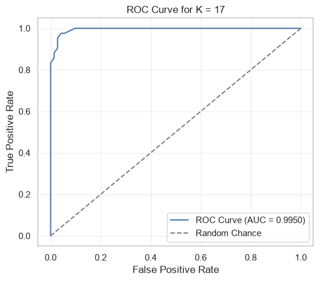

```python
fpr, tpr, thresholds = roc_curve(y_test_80, final_probabilities)
roc_auc = roc_auc_score(y_test_80, final_probabilities)

plt.figure(figsize=(6, 5))
plt.plot(fpr, tpr, color='#4C78A8', label=f'ROC Curve (AUC = {roc_auc:.4f})')
plt.plot([0, 1], [0, 1], color='gray', linestyle='--', label='Random Chance')
plt.title(f'ROC Curve for K = {final_best_k}')
plt.xlabel('False Positive Rate')
plt.ylabel('True Positive Rate')
plt.legend(loc='lower right')
plt.grid(True, alpha=0.3)
plt.show()
```

Inference: A curve closer to the top-left corner means better classification performance. A higher ROC-AUC means the model separates the two classes more effectively.

Task 6: Comparative Study with Regression (Lab 3 Integration)

Regression evaluation focuses on measuring the magnitude of prediction errors, whereas classification evaluation focuses on whether the predicted class label is correct.

R² Score vs Accuracy: R² Score measures how well a regression model explains the variation in continuous target values. Accuracy measures the percentage of correctly classified samples. Both indicate overall model performance, but they are used for different prediction tasks.

RMSE vs F1-Score: RMSE measures the average prediction error while giving higher weight to larger errors. F1-Score combines Precision and Recall into a single metric and evaluates the balance between correctly identifying positive cases and avoiding false predictions.

MAE vs Confusion Matrix: MAE calculates the average absolute difference between predicted and actual values in regression. The Confusion Matrix summarizes classification outcomes by showing True Positives, True Negatives, False Positives, and False Negatives, providing detailed insight into prediction correctness.

Continuous Prediction vs Classification: Regression predicts continuous numerical values such as GPA or medical costs, and its performance is evaluated based on prediction errors. Classification predicts discrete class labels such as benign or malignant, and its performance is evaluated based on correct and incorrect decisions.

Inference

Regression metrics such as MAE, MSE, RMSE, and R² Score evaluate how close predicted values are to the actual continuous values. Lower MAE, MSE, and RMSE indicate better prediction accuracy, while a higher R² Score indicates that the model explains more variation in the data. These metrics measure the magnitude of prediction errors rather than whether a decision is correct. This evaluation approach was used in Lab 3 to assess Linear Regression performance.

Classification metrics evaluate the correctness of predicted class labels instead of numerical errors. Accuracy measures overall correctness, Precision measures the correctness of positive predictions, Recall measures the ability to detect actual positive cases, F1-Score balances Precision and Recall, and ROC-AUC measures the model's ability to distinguish between classes across different thresholds.

Accuracy alone is insufficient for medical diagnosis because a model may achieve high accuracy while still missing patients with cancer. False negatives are more critical than false positives in healthcare. Therefore, Recall is essential because it minimizes missed cancer cases, and ROC-AUC provides a threshold-independent measure of the model's discrimination ability. Overall, regression evaluation emphasizes prediction error, whereas classification evaluation emphasizes decision quality and reliable identification of class labels.

Task 7 - Analytical Questions

1. **Why is KNN called a lazy learning algorithm?** KNN does not build a separate training model during the learning stage. It stores the training data and waits until prediction time to compute distances. That is why it is called lazy learning.
2. **Why is feature scaling required in KNN?** KNN depends on distance, so features with larger numeric ranges can dominate the result. Scaling puts every feature on a similar scale. This makes the distance calculation fair.
3. **Explain heuristic K selection using √n.** A common rule is to start with K equal to the square root of the number of training samples. This gives a reasonable balance between noise sensitivity and smoothing. The value is often adjusted to an odd number to avoid ties.
4. **Why is cross-validation more reliable than a single train-test split?** Cross-validation tests the model on several different folds of the data. This gives a more stable estimate of performance. A single split can depend too much on one random division.
5. **How does K affect the bias-variance trade-off?** Small K values usually give low bias and high variance. Large K values usually give higher bias and lower variance. The best K gives a balanced result.
6. **Why is Recall more important than Accuracy in cancer prediction?** Recall checks how many actual cancer cases are found by the model. Missing a real cancer case can be very dangerous. That is why recall is often more important than accuracy in this task.
7. **What is the limitation of very large K values?** Very large K values make the model too smooth. It can ignore useful local patterns in the data. This can lead to underfitting and weaker predictions.

Conclusion

The dataset was loaded, checked for missing values and duplicates, encoded, and scaled for KNN. Feature scaling helped the distance-based model treat all features more fairly. The train-test split and K experiments showed which setup performed best on the holdout data.

The final K value was selected using both holdout testing and cross-validation. The final model was then evaluated with accuracy, precision, recall, F1 score, ROC-AUC, a confusion matrix, and an ROC curve. Recall and ROC-AUC are especially important here because cancer screening should avoid missing positive cases.

Regression evaluation focuses on prediction error, while classification evaluation focuses on correct class decisions. In medical diagnosis, classification metrics are more useful because the goal is to detect the disease case correctly.